# mixed models: challenges and frontiers

18 November 2025

## Table of contents

## Inference details

## Confidence intervals/\(p\)-values

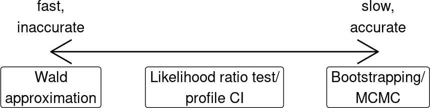

- easy methods work better as number of observations *and* number of clusters grow
- easy methods better for fixed effects than for RE variances

## Wald approximation: hypothesis tests

- assumes log-quadratic likelihood surface  
  (exact for linear models)
- output of `summary()` (and `car::Anova()`, `afex::anova()`)
- contrasts/post-hoc tests: `emmeans`
- especially unreliable for random-effects (co)variances/correlations
- confidence intervals: `confint(., method = "Wald")` (fixed only)

## Degrees of freedom

- account for uncertainty in variance estimation (\(Z\) vs \(t\))
- matters when number of groups is ‘small’ (<50?)
- level-counting: `nlme::lme()`, `R/calcDenDF.R`
- `lmerTest`/`afex`; Satterthwaite:

```
##             Estimate Std. Error     df t value Pr(>|t|)
## (Intercept)   251.04       8.72  12.12   28.80  1.6e-12
## Days            9.69       2.09  12.26    4.63  0.00055
```

- Kenward-Roger: only applicable to REML fits (LMMs?); also adjusts variances

```
##             Estimate Std. Error     df t value Pr(>|t|)
## (Intercept)   251.04       8.72  11.99   28.79    2e-12
## Days            9.69       2.10  11.86    4.62  0.00061
```

## Likelihood ratio test/profile confidence intervals

- individual parameters: `profile()`, `confint()`
- fit pairwise models and use `anova()` to compare
- `drop1`, `afex::anova()`

```
##                                2.5 %  97.5 %
## sd_(Intercept)|Subject        13.933  43.987
## cor_Days.(Intercept)|Subject  -0.528   0.796
## sd_Days|Subject                4.072  10.732
## sigma                         23.757  31.341
## (Intercept)                  233.352 268.740
## Days                           5.433  13.929
```

## Likelihood profiles

Why did `confint()` take so long?

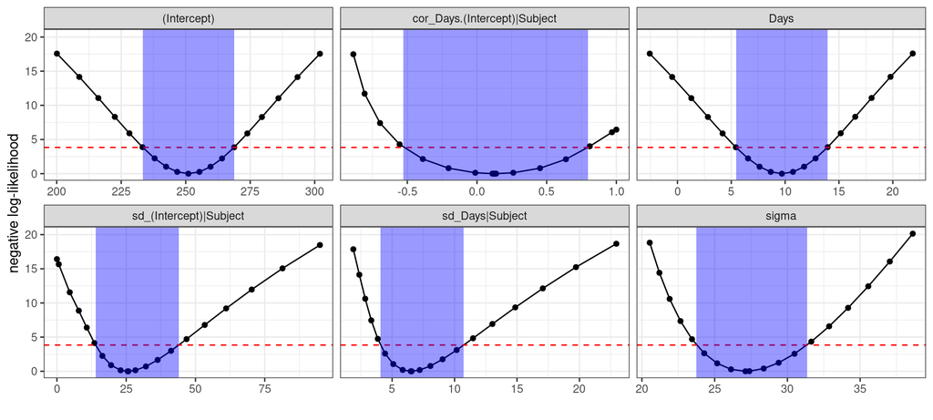

## Likelihood ratio tests of variances are problematic

- theory of LRT fails when \(H_0\) is “on the boundary”
- e.g. testing whether variance is 0
- simplest cases, conservative (\(p\)-vals are 2X nominal)
- do you really need to hypothesis-test random effects?
- bootstrapping …

## Predictive simulation

- `simulate()` new data from fitted model
- parameters fixed at best estimates (unlike nonpar bootstrap)
- can either use ‘estimated’ conditional modes or draw new random values
- does *not* include parameter uncertainty

## Troubleshooting

## What is a “singular fit”?

- non-positive-definite covariance matrix
- zero variance (simple case)
- ±1 correlation (next simplest case)
- hard to recognize in the general case!
- some linear combination(s) of random-effect variables have zero variance

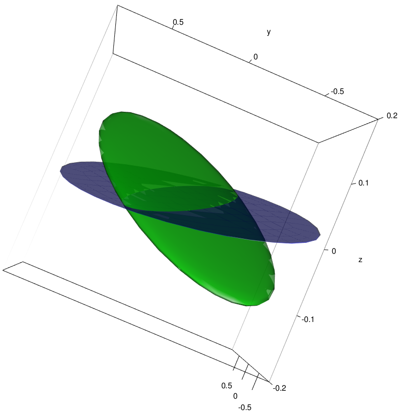

## Why are fits singular?

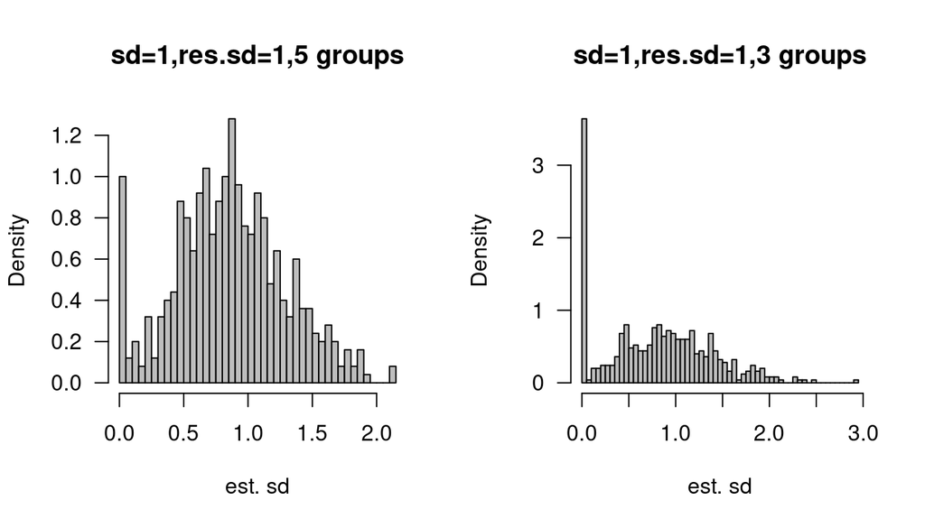

## What to do about singular fits?

- ignore them, or drop terms
- switch from random to fixed effects
- regularize/add priors
- simplify the model
- full Bayesian treatment

## Ignoring/dropping terms

- Zero variances/singular fits *are not a mistake*; they’re the best fit to the data
- Dropping a (full) singular term gives the same results/predictions/etc.
  - It does narrow confidence intervals (if using profile CIs)

## Switch from random to fixed effects

- especially for top-level clusters with few levels
- admit you can’t estimate the variance (RE variance \(\to \infty\))
  - more conservative than dropping/pooling (RE variance = 0)
- e.g. *Arabidopsis*: region (3) / population (9) / genotype (24), use `~ reg + (1|(reg:population)/genotype)`

## Regularize/add priors

- Bayesians don’t care about singular fits  
  (they look at the whole posterior distribution, not just the MLE/mode)
- quasi-Bayesian approach: *regularize*
- add a penalty (== prior) to keep estimates away from zero/boundaries
- Chung et al. (2013): add a weak prior that prevents singularity
- `blme`, `glmmTMB` + prior specification
- regularization useful in other cases (e.g. complete separation in logistic models)

## Simplifying random effect terms

- drop some varying effects
  - e.g. random intercepts and slopes → random intercepts only
- set correlations among parameters to zero (diagonal covariance matrix)
- set all correlations among parameters equal (*compound symmetric* model)
- *reduced rank* models

## Simplifying covariance matrices

- Suppose factor `f` (5 levels) varies within groups `g`
- `(1+f|g)`: \((n(n+1))/2 = (5\times 6)/2 = 15\) parameters)

\[ \newcommand{\oneentryone}{\sigma^2_{\{\scriptscriptstyle g|1\}}} \newcommand{\oneentry}[1]{\sigma^2_{\{\scriptscriptstyle g|f_{#1}\}}} \newcommand{\twoentry}[2]{\sigma_{\scriptscriptstyle \{g|f_{#1}\},\{g|f_{#2}\}}} \newcommand{\twoentryone}[1]{\sigma_{\scriptscriptstyle \{g|1\},\{g|f_{#1}\}}} \left[ \begin{array}{ccccc} \oneentryone & . & . & . & . \\ \twoentryone{21} & \oneentry{21} & . & . & . \\ \twoentryone{31} & \twoentry{21}{31} & \oneentry{31} & . & . \\ \twoentryone{41} & \twoentry{21}{41} & \twoentry{31}{41} & \oneentry{41} & . \\ \twoentryone{51} & \twoentry{21}{51} & \twoentry{31}{51} & \twoentry{41}{51} & \oneentry{51} \end{array} \right] \]

## Sum-to-zero contrasts

- change from *treatment* to *sum-to-zero* contrasts
- coefficients are means of each level, not baseline/differences from baseline

\[ \left[ \begin{array}{ccccc} \oneentry{1} & . & . & . & . \\ \twoentry{1}{2} & \oneentry{2} & . & . & . \\ \twoentry{1}{3} & \twoentry{2}{3} & \oneentry{3} & . & . \\ \twoentry{1}{4} & \twoentry{2}{4} & \twoentry{3}{4} & \oneentry{4} & . \\ \twoentry{1}{5} & \twoentry{2}{5} & \twoentry{3}{5} & \twoentry{4}{5} & \oneentry{5} \end{array} \right] \]

## Complex random intercepts (Scandola et al. 2024)

- replace `(1+f|g)` with `(1|g/f)`

\[ \Sigma = \left[ \begin{array}{ccccc} \sigma^2 & . & . & . & . \\ \rho \sigma^2 & \sigma^2 & . & . & . \\ \rho \sigma^2 & \rho \sigma^2 & \sigma^2 & . & . \\ \rho \sigma^2 & \rho \sigma^2 & \rho \sigma^2 & \sigma^2 & . \\ \rho \sigma^2 & \rho \sigma^2 & \rho \sigma^2 & \rho \sigma^2 & \sigma^2 \end{array} \right] \]

- where \(\sigma^2 = \sigma^2_{f}+\sigma^2_{g}\), \(\rho = \frac{\sigma^2_{g}}{\sigma^2}\)
- \(\rho>0\); all variances identical
- *compound symmetry*: `cs()` (`glmmTMB`), `corCompSymm` (`nlme`)

## Diagonal covariance matrices

- `(1+x+y+z||b)` or `diag(1+x+y+z|b)`
  - or `(1|b) + (0+x|b) + ...`
- `lme4` version **only works properly for continuous predictors**
- `afex::mixed` can do this
- contrasts/centering matters!
- \(n\) instead of \(n(n+1)/2\) parameters

## Reduced-rank covariance matrices

- ‘factor analytic’ or ‘reduced rank’
- \(d\)-dimensional covariance matrix in a \(p\)-dimensional space
- \(\Sigma = \Lambda D \Lambda^\top\) (\(\Lambda\) is the *factor loading matrix*)
- \(d \cdot p - \frac{d(d-1)}{2}\) parameters (linear in \(p\))
- available in R: `glmmTMB`, `sommer`, `lme4breeding`: ASReml

## Convergence failures

- convergence failures are common
- what do they really mean? how to fix them? when can they be ignored?
- **approximate** test that gradient=0 and curvature is correct
- scale and center predictors; simplify model
- use `?allFit` to see whether different optimizers give sufficiently similar answers
  - `$fixef`, etc.: are answers sufficiently similar?
  - `$llik`: how similar is goodness-of-fit?

## Which model to use?

- Barr et al. (2013): “keep it maximal”; reduce until no more convergence failures
- Bates et al. (2015), Matuschek et al. (2017): more parsimony
- R. Kliegl: best non-singular
  - make singular terms diagonal
  - drop elements with small variances
  - try full (unstructured) model with only these elements
- brute-force: non-singular, best AIC (Moritz et al. 2023)
- inspect principal components of covariance matrix? (`rePCA`)

## Smooth terms

- can use mixed-model/latent-variable frameworks to fit smooth *functional* terms
- additive models (penalized regression): add penalty \(\sigma^2 b S b^\top\)
- exactly equivalent to the random-effects component in a mixed model
- Wahba (1990); Wood (2017); Hefley et al. (2017); Pedersen et al. (2018)
- `mgcv`, `gamm4`, `glmmTMB`

## ‘Old’ and ‘new’ random effects (Hodges 2016)

- do random effects/latent variables represent differences among exchangeable groups …
- … or spatial/temporal/functional structure? (Wood 2017)
- prediction/inference: population level or the cluster level (Vaida et al. 2005) ?
- counting parameters?

[figure not shown]

## Big data?

## The need for speed

Brooks et al. (2017) (negative binomial model)

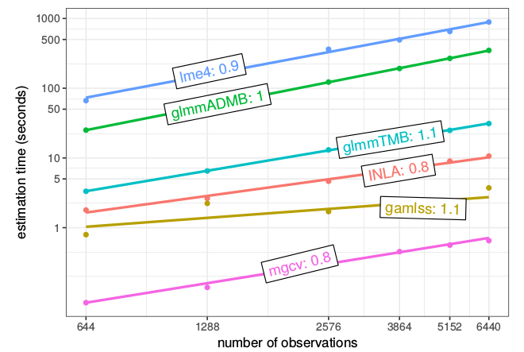

## more speed

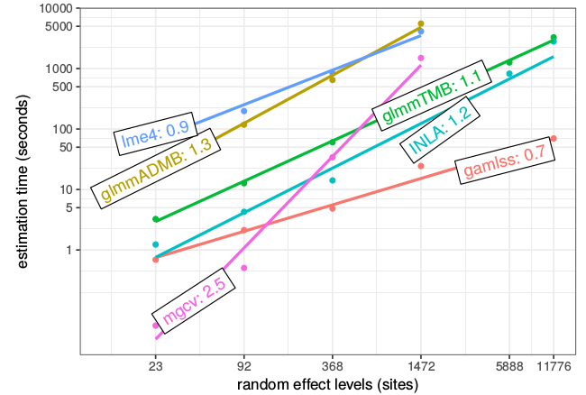

## Julia/R benchmark

- Poisson model, 98K rows/151 groups (Markwick 2022)

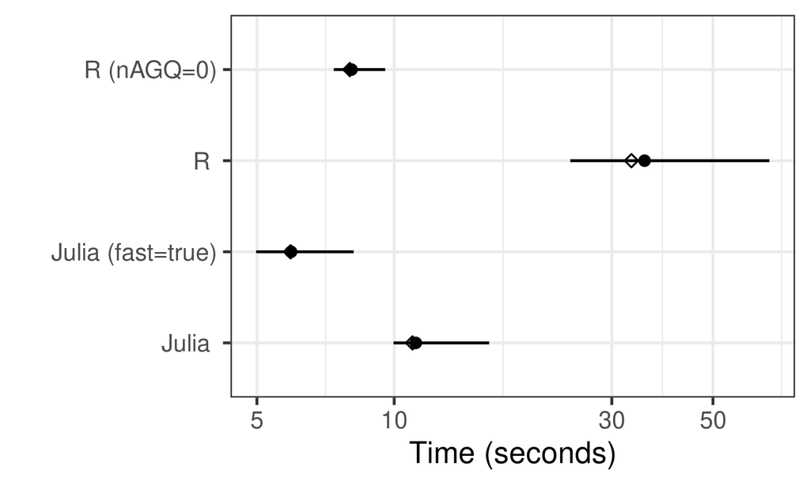

## Scalable mixed models

- Gao et al. (2020); Ghosh et al. (2022); Bellio et al. (2025)
- \({\cal O}(N)\) methods (`lme4` etc. are \({\cal O}(N^{3/2})\))
- StitchFix data: 5M observations, 6.3K items, 762K clients

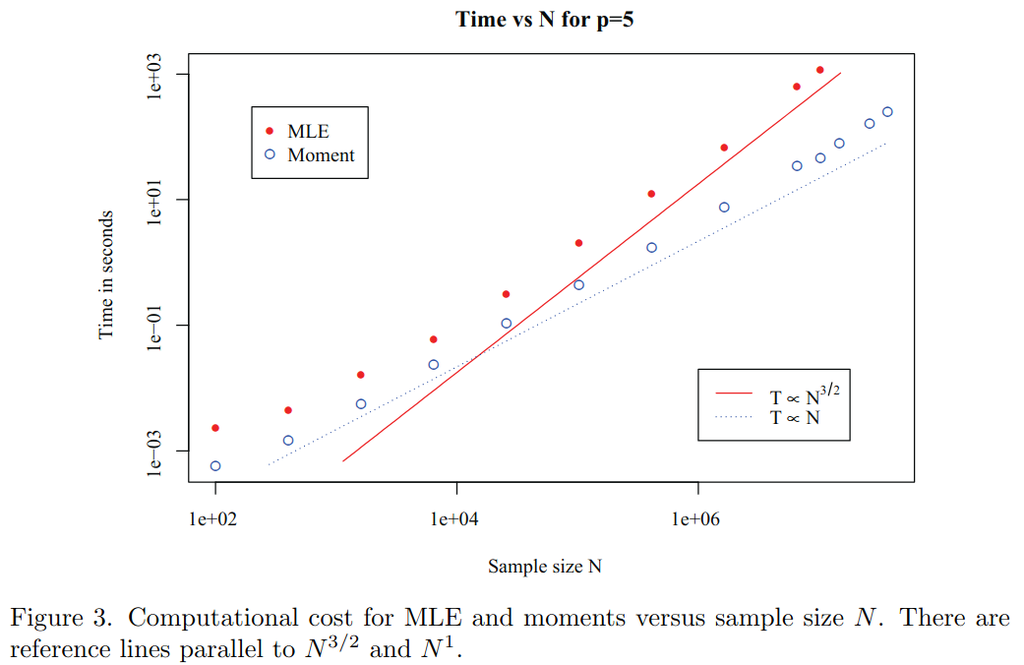

## Challenges and open questions

## On beyond `lme4`

- `glmmTMB`: zero-inflation, weird conditional distributions
- `MCMCglmm`, `brms`,`rstanarm`: Bayesian
- `gllvm`: multivariate ecological/phylogenetic data
- `INLA`: great for spatial and temporal structures
- [rethinking package](https://github.com/rmcelreath/rethinking)

## Toolboxes

- JAGS (R: `rjags`, `r2jags`)
- TensorFlow (R: `greta`)
- NIMBLE (R: `nimble` package)
- Stan (R: `rstan`)
- TMB (R: `TMB`, `RTMB`)

## On beyond R

- Julia: `MixedModels.jl`
- SAS: PROC MIXED, NLMIXED
- AS-Reml
- Stata (GLLAMM, xtmelogit)
- HLM, MLWiN
- Python? (`pymer4`, `statsmodels`)

[figure not shown]

## Package comparison

| Capability | lme4 | GLMMadaptive | glmmTMB | mgcv | nlme | glmmrBase |
| --- | --- | --- | --- | --- | --- | --- |
| Linear mixed models | ✅ | ❌ | ✅ | ✅ | ✅ | ✅ |
| GLMMs | ✅ | ✅ | ✅ | ⚠️ | ❌ | ✅ |
| Laplace approximation | ✅ | ❌ | ✅ | ✅ (PQL) | ✅ | ✅ |
| Gauss–Hermite quadrature | ✅ (limited) | ✅ | ❌ | ❌ | ❌ | ❌ |
| Structured covariance (CS/AR1/etc.) | ⚠️ | ❌ | ✅ | ✅ | ✅ | ✅ |
| Space/time covariance | ❌ | ❌ | ✅ | ⚠️ | ✅ | ✅ |
| Heteroscedasticity | ❌ | ⚠️ | ✅ | ⚠️ | ✅ | ✅ |

## Challenges

- Small clusters: need AGQ/MCMC
- Small numbers of clusters: need finite-size corrections
- Small data sets: singular fits, model selection
- Ever-expanding (desired) feature matrix; downstream ecosystems
- Big data: speed!

## references

Barr, DJ et al. 2013. *Journal of Memory and Language* 68 (3) (April): 255–278. doi:10.1016/j.jml.2012.11.001.

Bates, D et al. 2015. *arXiv:1506.04967 [stat]* (June). http://arxiv.org/abs/1506.04967.

Bellio, R et al. 2025. *Biometrika* 112 (3) (August): asaf037. doi:10.1093/biomet/asaf037.

Brooks, ME et al. 2017. *R Journal* 9: 378–400. doi:10.32614/RJ-2017-066.

Byrnes, JEK et al. 2025. *Ecology Letters* 28 (1): e70023. doi:10.1111/ele.70023. https://onlinelibrary.wiley.com/doi/abs/10.1111/ele.70023.

Chung, Y et al. 2013. *Psychometrika*: 1–25. doi:10.1007/s11336-013-9328-2.

Elston, DA et al. 2001. *Parasitology* 122 (5): 563–569.

Franks, DW et al. 2025. *Biological Reviews* 100 (5): 1950–1969. doi:10.1111/brv.70029. https://onlinelibrary.wiley.com/doi/abs/10.1111/brv.70029.

Gao, K et al. 2020. *Statistica Sinica*. doi:10.5705/ss.202018.0029.

Ghosh, S et al. 2022. *Electronic Journal of Statistics* 16 (2) (January): 4604–4635. doi:10.1214/22-EJS2047.

Harrison, XA. 2014. *PeerJ* 2 (October): e616. doi:10.7717/peerj.616. https://peerj.com/articles/616.

———. 2015. *PeerJ* 3 (July): e1114. doi:10.7717/peerj.1114. https://peerj.com/articles/1114.

He, H et al. 2019. *Statistical methods in medical research* 28 (4) (April): 1157–1169. doi:10.1177/0962280217749991.

Hefley, TJ et al. 2017. *Ecology* 98 (3): 632–646. doi:10.1002/ecy.1674.

Hilbe, Joseph M., ed. 2011. In *Negative Binomial Regression*, 141–184. 2nd ed. Cambridge: Cambridge University Press. doi:10.1017/CBO9780511973420.008. https://www.cambridge.org/core/books/negative-binomial-regression/overdispersion/1779F5E5E1CBAA5B75B1410BE6ECCA3B.

Hodges, JS. 2016. *Richly parameterized linear models: Additive, time series, and spatial models using random effects*. Chapman; Hall/CRC.

Jaeger, BC et al. 2017. *Journal of Applied Statistics* 44 (6) (April): 1086–1105. doi:10.1080/02664763.2016.1193725. https://doi.org/10.1080/02664763.2016.1193725.

Johnson, PCD. 2014. *Methods in Ecology and Evolution* 5 (9) (September): 944–946. doi:10.1111/2041-210X.12225. http://onlinelibrary.wiley.com/doi/10.1111/2041-210X.12225/abstract.

Markwick, D. 2022. https://dm13450.github.io/2022/01/06/Mixed-Models-Benchmarking.html.

Matuschek, H et al. 2017. *Journal of Memory and Language* 94: 305–315. doi:10.1016/j.jml.2017.01.001.

McElreath, R. 2015. *Statistical Rethinking: A Bayesian Course with Examples in R and Stan*. Boca Raton: Chapman; Hall/CRC.

Moritz, MA et al. 2023. *Ecology Letters* 26 (4): 563–574. doi:10.1111/ele.14177.

Nakagawa, S et al. 2013. *Methods in Ecology and Evolution* 4 (2) (February): 133–142. doi:10.1111/j.2041-210x.2012.00261.x. http://doi.wiley.com/10.1111/j.2041-210x.2012.00261.x.

Nakagawa, S et al. 2017. *Journal of The Royal Society Interface* 14 (134) (September): 20170213. doi:10.1098/rsif.2017.0213. https://royalsocietypublishing.org/doi/full/10.1098/rsif.2017.0213.

Pedersen, EJ et al. 2018. *Hierarchical generalized additive models: An introduction with mgcv*. PeerJ Inc. doi:10.7287/peerj.preprints.27320v1.

Scandola, M et al. 2024. *Advances in Methods and Practices in Psychological Science* 7 (1) (January): 25152459231214454. doi:10.1177/25152459231214454.

Thai, H-T et al. 2013. *Pharmaceutical Statistics* 12 (3): 129–140. doi:10.1002/pst.1561.

Vaida, F et al. 2005. *Biometrika* 92 (2) (June): 351–370. doi:10.1093/biomet/92.2.351.

Wahba, G. 1990. *Spline models for observational data*. Philadelphia, PA: Society for Industrial and Applied Mathematics.

Warton, DI. 2005. *Environmetrics* 16 (3): 275–289. doi:10.1002/env.702. http://dx.doi.org/10.1002/env.702.

Wilson, P. 2015. *Economics Letters* 127 (February): 51–53. doi:10.1016/j.econlet.2014.12.029.

Wood, S. 2017. *Generalized additive models: An introduction with R*. 2d ed. CRC texts in statistical science. Chapman; Hall.

## extras

## \(R^2\)

- goodness-of-fit measures for LMMs, and for GLMMs, are hard
- meanings of \(R^2\) (variance explained; \(\textrm{corr}(\textrm{obs}, \textrm{predicted})^2\); etc. don’t coincide
- *pseudo*-\(R^2\) for GLMs (MacFadden, Nagelkerke, etc.)
- various [Jaeger et al. (2017)
- Nakagawa/Schielzeth/Johnson most popular (Nakagawa et al. 2013; Johnson 2014; Nakagawa et al. 2017)
- (?but what about zero-inflation, new distributions, etc. etc. etc.)

## Overdispersion

- “too much” variability (relative to theoretical expectation)
- very serious for fixed-dispersion families (Poisson, binomial)
- conjugate-family distributions (negative binomial, Beta-binomial)
- observation-level random effects (Elston et al. 2001; Harrison 2014; Harrison 2015)
- unidentifiable for binary data (unless groupable), Gaussian data
- little concern for families with estimated scale/dispersion (but see Hilbe (2011))

## Zero-inflation

- “many zeros does not mean zero-inflation” (Warton 2005)
- can’t use Vuong test (Wilson 2015; He et al. 2019)
- `glmmTMB` or use expectation-maximization (see [here](https://stats.stackexchange.com/q/208829/2126))
- `DHARMa` can test by simulation

## Causal inference

- I don’t go there very much
- Solve many issues by adding *group mean* as a covariate (Byrnes et al. 2025)
- Awareness of *general* causal issues: DAGs, mediation/confounding, etc.. (McElreath 2015; Franks et al. 2025)

## Heteroscedasticity

- can be an issue (especially among groups)
- log transformation (for continuous positive data) often resolves both linearity and heteroscedasticity
- `glmmTMB`, `nlme`
- build into observation-level REs